# Bellabeat

SundriedTomato

3/26/2022

## Google Data Analytics Capstone - Case Study 2

### How Can a Wellness Company Play it Smart?

#### Business Task:

Analyze FitBit fitness tracker data to gain insights into how consumers use the FitBit app and discover trends for Bellabeat marketing strategy.

##### Business Objectives:

What are the trends identified? How could these trends apply to Bellabeat customers? How could these trends help influence Bellabeat marketing strategy?

##### Information on Data Source:

Data is publicly available on Kaggle: FitBit Fitness Tracker Data and stored in 18 CSV files.  
The data is generated by respondents from a survey between March 12, 2016, and May 12, 2016.  
30 FitBit users consented to the submission of personal tracker data. Data collected includes physical activity recorded in minutes, heart rate, sleep monitoring, daily activity data, and steps.

##### Limitations of Data Set:

The data was collected five years ago, in 2016. Since then, users’ daily activity, fitness and sleeping habits, diet, and food consumption may have changed. Data may not be timely or relevant.  
A sample size of 30 FitBit users does not represent the entire fitness population or even the entire FitBit community.  
The data was collected from a survey. We are unable to ascertain its integrity or accuracy.

##### Is Data ROCCC?

- Reliable — VERY LOW — data from only 30 people.
- Original — LOW — Third party provider.
- Comprehensive — MEDIUM — The data mostly matches up with data needed for the business task.
- Current — LOW — Data is over 5 years old and may not be relevant anymore based on recent events.
- Cited — LOW — Data collected from third party. Unknown if cited.

##### tools:

R - for data cleaning, transformation and visualization.

```r
library(tidyverse) #Exploring, plotting and wrangling the data
library(lubridate) #working with the dates
library(ggExtra) #to complement ggplot
library(patchwork) #complement ggplot to combine graphs
library(DT) #Data table
library(ggthemes) #ggplot themes

options(scipen=999) #turn off scientific notation
```

```r
#get a list of all the files in the working directory
source_files <- list.files(pattern = "\\.csv$")

#read the files to the global environment
for (i in source_files) {
  assign(substr(i,1,nchar(i)-4), read.csv(i))
}

#glimpse all the data to get an idea of what it looks like
for (i in source_files) {
  glimpse(get(substr(i,1,nchar(i)-4)))
}
```

```
## Rows: 940
## Columns: 16
## $ X                        <int> 1, 2, 3, 4, 5, 6, 7, 8, 9, 10, 11, 12, 13, 14~
## $ Id                       <dbl> 1503960366, 1503960366, 1503960366, 150396036~
## $ ActivityDate             <chr> "4/12/2016", "4/13/2016", "4/14/2016", "4/15/~
## $ TotalSteps               <int> 13162, 10735, 10460, 9762, 12669, 9705, 13019~
## $ TotalDistance            <dbl> 8.50, 6.97, 6.74, 6.28, 8.16, 6.48, 8.59, 9.8~
## $ TrackerDistance          <dbl> 8.50, 6.97, 6.74, 6.28, 8.16, 6.48, 8.59, 9.8~
## $ LoggedActivitiesDistance <dbl> 0, 0, 0, 0, 0, 0, 0, 0, 0, 0, 0, 0, 0, 0, 0, ~
## $ VeryActiveDistance       <dbl> 1.88, 1.57, 2.44, 2.14, 2.71, 3.19, 3.25, 3.5~
## $ ModeratelyActiveDistance <dbl> 0.55, 0.69, 0.40, 1.26, 0.41, 0.78, 0.64, 1.3~
## $ LightActiveDistance      <dbl> 6.06, 4.71, 3.91, 2.83, 5.04, 2.51, 4.71, 5.0~
## $ SedentaryActiveDistance  <dbl> 0, 0, 0, 0, 0, 0, 0, 0, 0, 0, 0, 0, 0, 0, 0, ~
## $ VeryActiveMinutes        <int> 25, 21, 30, 29, 36, 38, 42, 50, 28, 19, 66, 4~
## $ FairlyActiveMinutes      <int> 13, 19, 11, 34, 10, 20, 16, 31, 12, 8, 27, 21~
```

[output cut: 308 more lines]

```r
#Looks like dailyActivity_merged has data from the other daily tables. so we can remove those
rm(dailyActivity,dailyCalories_merged,dailyIntensities_merged,dailySteps_merged)

#remove minute by minute data. It won't help for our business talk
rm(minuteStepsWide_merged,minuteStepsNarrow_merged,minuteSleep_merged,
   minuteMETsNarrow_merged,minuteCaloriesNarrow_merged,minuteCaloriesWide_merged,
   minuteIntensitiesNarrow_merged,minuteIntensitiesWide_merged)

#check the daily activity for nulls or missing data or anything off
sum(is.null(dailyActivity_merged))
```

```
## [1] 0
```

```r
sum(is.na(dailyActivity_merged))
```

```
## [1] 0
```

Next, I look over the main data frame on a table to flip through it and get a general sense of what it looks like on a table.

```r
datatable(head(dailyActivity_merged,100), rownames = TRUE, filter="top",
          options = list(pageLength = 6, scrollX=T) )
```

|  | X | Id | ActivityDate | TotalSteps | TotalDistance | TrackerDistance | LoggedActivitiesDistance | VeryActiveDistance | ModeratelyActiveDistance | LightActiveDistance | SedentaryActiveDistance | VeryActiveMinutes | FairlyActiveMinutes | LightlyActiveMinutes | SedentaryMinutes | Calories |
| --- | --- | --- | --- | --- | --- | --- | --- | --- | --- | --- | --- | --- | --- | --- | --- | --- |
| 1 | 1 | 1503960366 | 4/12/2016 | 13162 | 8.5 | 8.5 | 0 | 1.87999999523163 | 0.550000011920929 | 6.05999994277954 | 0 | 25 | 13 | 328 | 728 | 1985 |
| 2 | 2 | 1503960366 | 4/13/2016 | 10735 | 6.96999979019165 | 6.96999979019165 | 0 | 1.57000005245209 | 0.689999997615814 | 4.71000003814697 | 0 | 21 | 19 | 217 | 776 | 1797 |
| 3 | 3 | 1503960366 | 4/14/2016 | 10460 | 6.73999977111816 | 6.73999977111816 | 0 | 2.44000005722046 | 0.400000005960464 | 3.91000008583069 | 0 | 30 | 11 | 181 | 1218 | 1776 |
| 4 | 4 | 1503960366 | 4/15/2016 | 9762 | 6.28000020980835 | 6.28000020980835 | 0 | 2.14000010490417 | 1.25999999046326 | 2.82999992370605 | 0 | 29 | 34 | 209 | 726 | 1745 |
| 5 | 5 | 1503960366 | 4/16/2016 | 12669 | 8.15999984741211 | 8.15999984741211 | 0 | 2.71000003814697 | 0.409999996423721 | 5.03999996185303 | 0 | 36 | 10 | 221 | 773 | 1863 |
| 6 | 6 | 1503960366 | 4/17/2016 | 9705 | 6.48000001907349 | 6.48000001907349 | 0 | 3.19000005722046 | 0.779999971389771 | 2.50999999046326 | 0 | 38 | 20 | 164 | 539 | 1728 |
| 7 | 7 | 1503960366 | 4/18/2016 | 13019 | 8.59000015258789 | 8.59000015258789 | 0 | 3.25 | 0.639999985694885 | 4.71000003814697 | 0 | 42 | 16 | 233 | 1149 | 1921 |
| 8 | 8 | 1503960366 | 4/19/2016 | 15506 | 9.88000011444092 | 9.88000011444092 | 0 | 3.52999997138977 | 1.32000005245209 | 5.03000020980835 | 0 | 50 | 31 | 264 | 775 | 2035 |
| 9 | 9 | 1503960366 | 4/20/2016 | 10544 | 6.67999982833862 | 6.67999982833862 | 0 | 1.96000003814697 | 0.479999989271164 | 4.23999977111816 | 0 | 28 | 12 | 205 | 818 | 1786 |
| 10 | 10 | 1503960366 | 4/21/2016 | 9819 | 6.34000015258789 | 6.34000015258789 | 0 | 1.3400000333786 | 0.349999994039536 | 4.65000009536743 | 0 | 19 | 8 | 211 | 838 | 1775 |

[output cut: 90 more lines]

```r
summary(sleepDay_merged)
```

```
##        Id               SleepDay         TotalSleepRecords TotalMinutesAsleep
##  Min.   :1503960366   Length:413         Min.   :1.000     Min.   : 58.0
##  1st Qu.:3977333714   Class :character   1st Qu.:1.000     1st Qu.:361.0
##  Median :4702921684   Mode  :character   Median :1.000     Median :433.0
##  Mean   :5000979403                      Mean   :1.119     Mean   :419.5
##  3rd Qu.:6962181067                      3rd Qu.:1.000     3rd Qu.:490.0
##  Max.   :8792009665                      Max.   :3.000     Max.   :796.0
##  TotalTimeInBed
##  Min.   : 61.0
##  1st Qu.:403.0
##  Median :463.0
##  Mean   :458.6
##  3rd Qu.:526.0
##  Max.   :961.0
```

```r
n_distinct(sleepDay_merged$Id)
```

```
## [1] 24
```

Sleep data has very little provided data

```r
summary(weightLogInfo_merged)
```

```
##        Id                 Date              WeightKg       WeightPounds
##  Min.   :1503960366   Length:67          Min.   : 52.60   Min.   :116.0
##  1st Qu.:6962181067   Class :character   1st Qu.: 61.40   1st Qu.:135.4
##  Median :6962181067   Mode  :character   Median : 62.50   Median :137.8
##  Mean   :7009282135                      Mean   : 72.04   Mean   :158.8
##  3rd Qu.:8877689391                      3rd Qu.: 85.05   3rd Qu.:187.5
##  Max.   :8877689391                      Max.   :133.50   Max.   :294.3
##
##       Fat             BMI        IsManualReport         LogId
##  Min.   :22.00   Min.   :21.45   Length:67          Min.   :1460443631000
##  1st Qu.:22.75   1st Qu.:23.96   Class :character   1st Qu.:1461079185000
##  Median :23.50   Median :24.39   Mode  :character   Median :1461801599000
##  Mean   :23.50   Mean   :25.19                      Mean   :1461771594280
##  3rd Qu.:24.25   3rd Qu.:25.56                      3rd Qu.:1462375450500
##  Max.   :25.00   Max.   :47.54                      Max.   :1463097599000
##  NA's   :65
```

```r
n_distinct(weightLogInfo_merged$Id)
```

```
## [1] 8
```

Weight data was submitted the least based on the number of district Id’s.

```r
#check the hourly data
str(hourly)
```

```
## 'data.frame':    22099 obs. of  7 variables:
##  $ X               : int  1 2 3 4 5 6 7 8 9 10 ...
##  $ Id              : num  1503960366 1503960366 1503960366 1503960366 1503960366 ...
##  $ ActivityHour    : chr  "4/12/2016 1:00:00 AM" "4/12/2016 1:00:00 PM" "4/12/2016 10:00:00 AM" "4/12/2016 10:00:00 PM" ...
##  $ TotalIntensity  : int  8 6 29 9 12 21 20 11 7 36 ...
##  $ AverageIntensity: num  0.133 0.1 0.483 0.15 0.2 ...
##  $ Calories        : int  61 66 99 65 76 81 81 73 59 110 ...
##  $ StepTotal       : int  160 221 676 89 360 338 373 253 151 1166 ...
```

```r
str(hourlyCalories_merged)
```

```
## 'data.frame':    22099 obs. of  3 variables:
##  $ Id          : num  1503960366 1503960366 1503960366 1503960366 1503960366 ...
##  $ ActivityHour: chr  "4/12/2016 12:00:00 AM" "4/12/2016 1:00:00 AM" "4/12/2016 2:00:00 AM" "4/12/2016 3:00:00 AM" ...
##  $ Calories    : int  81 61 59 47 48 48 48 47 68 141 ...
```

```r
str(hourlyIntensities_merged)
```

```
## 'data.frame':    22099 obs. of  4 variables:
##  $ Id              : num  1503960366 1503960366 1503960366 1503960366 1503960366 ...
##  $ ActivityHour    : chr  "4/12/2016 12:00:00 AM" "4/12/2016 1:00:00 AM" "4/12/2016 2:00:00 AM" "4/12/2016 3:00:00 AM" ...
##  $ TotalIntensity  : int  20 8 7 0 0 0 0 0 13 30 ...
##  $ AverageIntensity: num  0.333 0.133 0.117 0 0 ...
```

```r
str(hourlySteps_merged)
```

```
## 'data.frame':    22099 obs. of  3 variables:
##  $ Id          : num  1503960366 1503960366 1503960366 1503960366 1503960366 ...
##  $ ActivityHour: chr  "4/12/2016 12:00:00 AM" "4/12/2016 1:00:00 AM" "4/12/2016 2:00:00 AM" "4/12/2016 3:00:00 AM" ...
##  $ StepTotal   : int  373 160 151 0 0 0 0 0 250 1864 ...
```

```r
#remove the hourly dfs. the main hourly df has all the info
rm(hourlyCalories_merged,hourlyIntensities_merged,hourlySteps_merged)
```

##### Analysis:

```r
summary(dailyActivity_merged)
```

```
##        X               Id             ActivityDate         TotalSteps
##  Min.   :  1.0   Min.   :1503960366   Length:940         Min.   :    0
##  1st Qu.:235.8   1st Qu.:2320127002   Class :character   1st Qu.: 3790
##  Median :470.5   Median :4445114986   Mode  :character   Median : 7406
##  Mean   :470.5   Mean   :4855407369                      Mean   : 7638
##  3rd Qu.:705.2   3rd Qu.:6962181067                      3rd Qu.:10727
##  Max.   :940.0   Max.   :8877689391                      Max.   :36019
##  TotalDistance    TrackerDistance  LoggedActivitiesDistance VeryActiveDistance
##  Min.   : 0.000   Min.   : 0.000   Min.   :0.0000           Min.   : 0.000
##  1st Qu.: 2.620   1st Qu.: 2.620   1st Qu.:0.0000           1st Qu.: 0.000
##  Median : 5.245   Median : 5.245   Median :0.0000           Median : 0.210
##  Mean   : 5.490   Mean   : 5.475   Mean   :0.1082           Mean   : 1.503
##  3rd Qu.: 7.713   3rd Qu.: 7.710   3rd Qu.:0.0000           3rd Qu.: 2.053
##  Max.   :28.030   Max.   :28.030   Max.   :4.9421           Max.   :21.920
##  ModeratelyActiveDistance LightActiveDistance SedentaryActiveDistance
##  Min.   :0.0000           Min.   : 0.000      Min.   :0.000000
##  1st Qu.:0.0000           1st Qu.: 1.945      1st Qu.:0.000000
##  Median :0.2400           Median : 3.365      Median :0.000000
##  Mean   :0.5675           Mean   : 3.341      Mean   :0.001606
##  3rd Qu.:0.8000           3rd Qu.: 4.782      3rd Qu.:0.000000
##  Max.   :6.4800           Max.   :10.710      Max.   :0.110000
##  VeryActiveMinutes FairlyActiveMinutes LightlyActiveMinutes SedentaryMinutes
##  Min.   :  0.00    Min.   :  0.00      Min.   :  0.0        Min.   :   0.0
##  1st Qu.:  0.00    1st Qu.:  0.00      1st Qu.:127.0        1st Qu.: 729.8
##  Median :  4.00    Median :  6.00      Median :199.0        Median :1057.5
##  Mean   : 21.16    Mean   : 13.56      Mean   :192.8        Mean   : 991.2
##  3rd Qu.: 32.00    3rd Qu.: 19.00      3rd Qu.:264.0        3rd Qu.:1229.5
##  Max.   :210.00    Max.   :143.00      Max.   :518.0        Max.   :1440.0
##     Calories
##  Min.   :   0
##  1st Qu.:1828
##  Median :2134
##  Mean   :2304
##  3rd Qu.:2793
##  Max.   :4900
```

From the data provided, specifically TotalSteps, the average number of steps per day is 7,600. CDC recommended daily average is 10,000. This data can be used for current customers to get them moving. The company can urge users to walk more and track their steps more carefully to improve health.

##### Plotting data explorations:

Looking at steps walked and calories burned. There is a clear positive

relationship between daily total steps and calories burned. Most of the users who submitted data walked less than 10,000 steps and burned close to 2,000 calories.

Generally, the more you walk, the more calories you’re likely to burn.

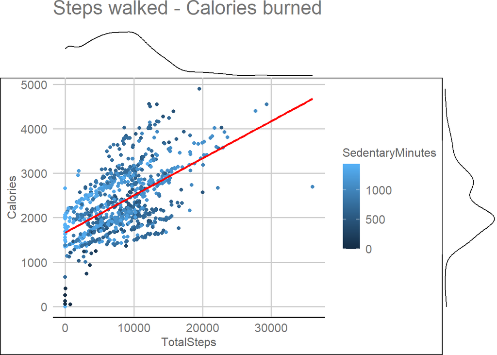

```r
a <- dailyActivity_merged %>% #compare total steps to calories
  ggplot(aes(TotalSteps,Calories, color = SedentaryMinutes)) + geom_point() +
  geom_smooth(method=lm , color="red", se=FALSE) +
  labs(title = "Steps walked - Calories burned") +
  theme_gdocs()
ggMarginal(a, type = "density")
```

When comparing sedentary time to calories, sedentary time is not necessarily related to calories burned. This tendency can be for any reason - one of which is going to the gym.

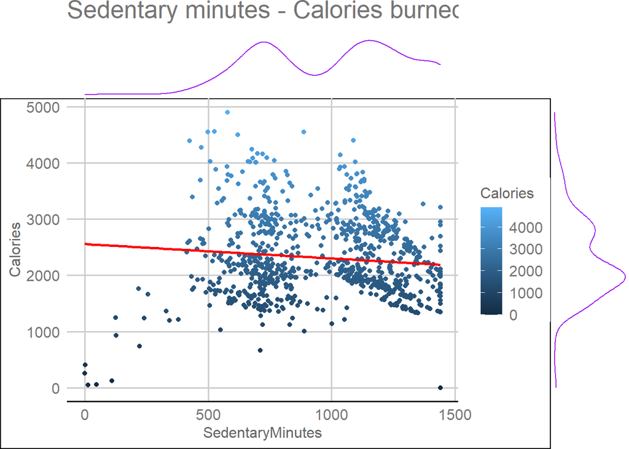

```r
b <- dailyActivity_merged %>% #compare sedentary minutes to calories
  ggplot(aes(SedentaryMinutes,Calories, color = Calories)) + geom_point() +
  geom_smooth(method=lm , color="red", se=FALSE) +
  labs(title = "Sedentary minutes - Calories burned") +
  theme_gdocs()
ggMarginal(b, type = "density", color = "purple")
```

```r
#we can see that with a correlation. almost 0
cor.test(dailyActivity_merged$SedentaryActiveDistance,
         dailyActivity_merged$Calories)
```

```
##
##  Pearson's product-moment correlation
##
## data:  dailyActivity_merged$SedentaryActiveDistance and dailyActivity_merged$Calories
## t = 1.3382, df = 938, p-value = 0.1812
## alternative hypothesis: true correlation is not equal to 0
## 95 percent confidence interval:
##  -0.02034679  0.10729427
## sample estimates:
##        cor
## 0.04365187
```

Next, we compare calories burned to active minutes: Looking at the data, we can see the more active you are, the more calories you tend to burn. This trend is good for marketing to new customers. Getting them to help track if they are moving enough.

The data also shows most of the users are only lightly active.

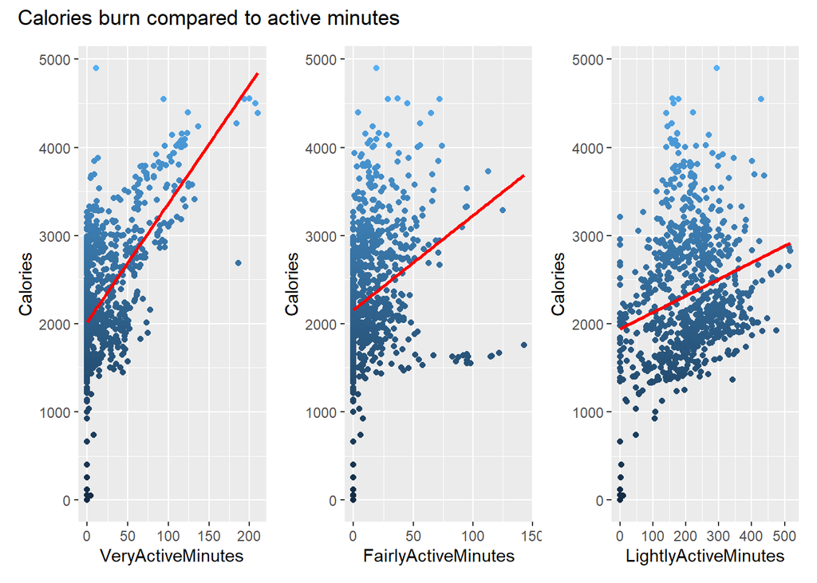

```r
#compare light minutes to calories. Not a strong correlation
c <- dailyActivity_merged %>%
  ggplot(aes(LightlyActiveMinutes,Calories, color = Calories)) + geom_point() +
  geom_smooth(method=lm , color="red", se=FALSE) + theme(legend.position="none")

d <- dailyActivity_merged %>% #compare fair minutes to calories
  ggplot(aes(FairlyActiveMinutes,Calories, color = Calories)) + geom_point() +
  geom_smooth(method=lm , color="red", se=FALSE) + theme(legend.position="none")

e <- dailyActivity_merged %>% #compare very minutes to calories
  ggplot(aes(VeryActiveMinutes,Calories, color = Calories)) + geom_point() +
  geom_smooth(method=lm , color="red", se=FALSE) + theme(legend.position="none")

(e + d + c) + plot_annotation(title = 'Calories burn compared to active minutes')
```

Looking at some day-by-day data, we see no logged data for the weekends. Either a product error or users don’t do any loggable activities on the weekends. (Running, swimming, other sports)

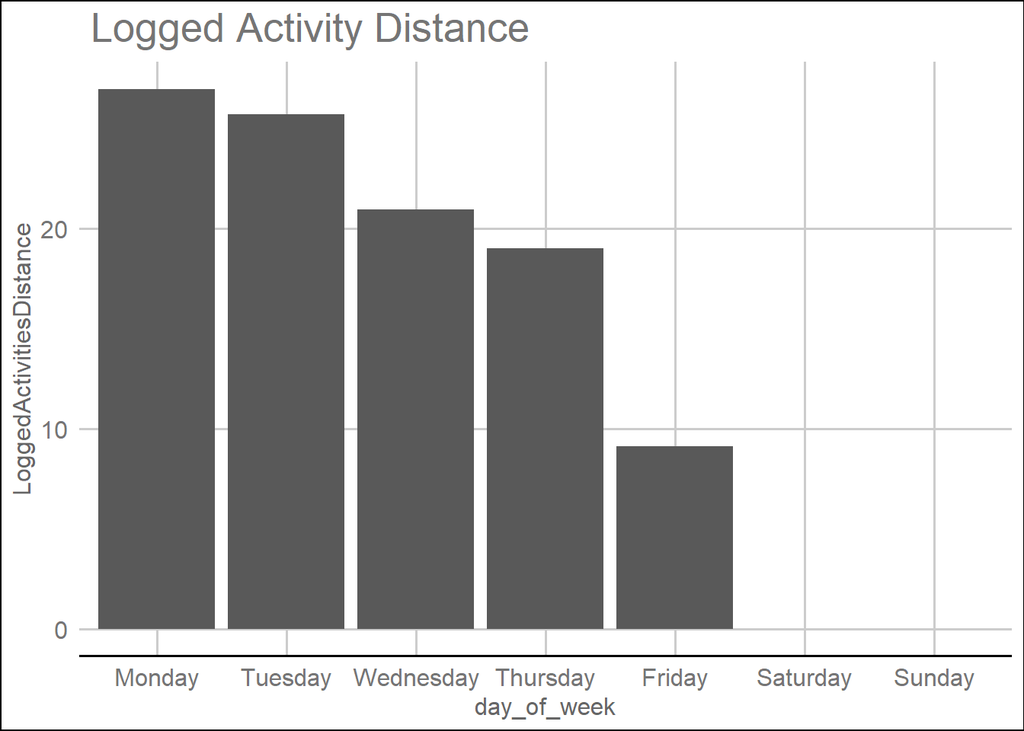

```r
#get days of the week
dailyActivity_merged$day_of_week <- format(as.POSIXct(dailyActivity_merged$ActivityDate, format = "%m/%d/%Y"), format = "%A")


dailyActivity_merged %>% #see which day has most active people
  mutate(day_of_week = factor(day_of_week, levels = c("Monday", "Tuesday",
                                                      "Wednesday", "Thursday",
                                                      "Friday", "Saturday",
                                                      "Sunday"))) %>%
  ggplot(aes(day_of_week, LoggedActivitiesDistance)) + geom_col() +
  labs(title = " Logged Activity Distance") + theme_gdocs()
```

Looking at the steps walked for each day of the week, there is no discernible trend with the limited data.

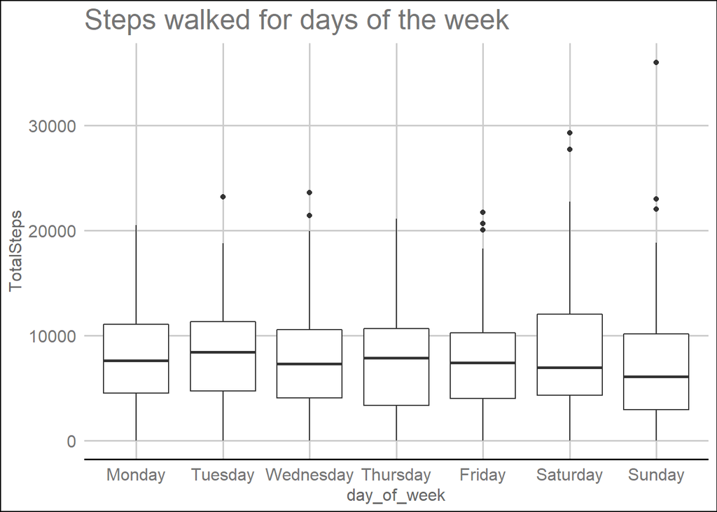

```r
dailyActivity_merged %>% #boxplot for steps on days of the week
  mutate(day_of_week = factor(day_of_week, levels = c("Monday",
                                                      "Tuesday",
                                                      "Wednesday", "Thursday",
                                                      "Friday", "Saturday",
                                                      "Sunday"))) %>%
  ggplot(aes(day_of_week, TotalSteps)) + geom_boxplot() +
  labs(title = "Steps walked for days of the week") + theme_gdocs()
```

##### Findings and recommendations:

###### What are the trends identified?

On average, users logged 7,638 steps. Per CDC recommendation, an adult should aim for 10,000 steps per day to benefit from general health. Source: https://www.cdc.gov/diabetes/prevention/pdf/postcurriculum_session8.pdf

Most of the 33 users that submitted data are sedentary and burn an average of 2304.

Users don’t log very much data on the weekends. (Running, swimming, other sports)

The more active minutes you have logged, the more calories you burned overall.

Users don’t track their weight data.

###### How could these trends apply to Bellabeat customers?

This data can get current customers to use the product more to track their steps and log more activities.

They can gamify or add events or notifications to help users keep track of their steps more and get them to move and do more activities overall but especially on the weekends. They can also encourage people to log their weight data more often to show them how their weight improved over time and how good that will feel. The product, right now, is rarely used to track sports or other activities based on the amount of active data logged.

###### How could these trends help influence Bellabeat marketing strategy?

Showing the correlation between how active you are and how many calories burned can be used to market the products to new customers.

Bellabeat can use the data to educate and equip users and potential users with knowledge about the benefits of fitness and fitness habits. They can suggest different exercises available with the product to help people meet their physical/weight/activity goals (simple exercise routines, outdoor activities, or encouraging people to do things like a swim or hike while logging the data).